# Financial Market

Session 1

Luis F. Gómez L.

luis.gomezl@unimilitar.edu.co

Distance Learning Faculty

10 February, 2026

# Please Read Me

- Check the message **Welcome greeting** published in Announcements forum.
- Dear student please edit your profile uploading a photo where your face is clearly visible.
- If you want to participate, please fill out the following survey: **Primer corte 30% > Learning Activities > Tu opinión sobre la economía colombiana**
- This presentation is based on (Cardenas, 2020, Chapter 8)
- **Purpose**
  - Analyze the functioning of the financial market, identifying the types of intermediaries and instruments that are part of it

# Structure of the Colombian financial system

- The financial system is the set of entities whose main function is to channel the money of savers to those who wish to make investments
  - We are only going to focus on supervised financial entities. Therefore entities outside the law or unregulated are not going to be analyzed
  - Also ponzi schemes, pyramids or unregulated investment scheme are not analyzed.
    - However if you are interested in this topic check out (Carvajal et al., 2009) and (Hofstetter et al., 2018)

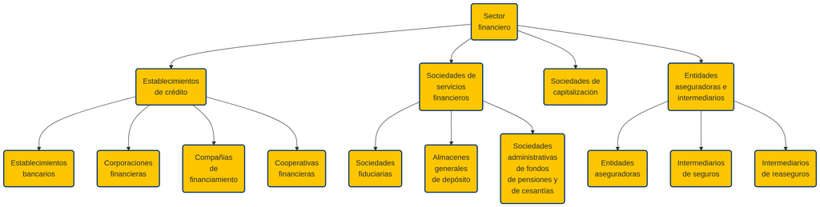

Figure 1: Financial system structure by supervised entities (Colombia, 1993)

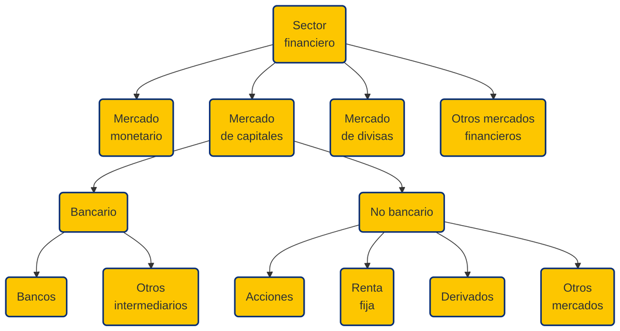

Figure 2: Financial system structure by markets entities (Cardenas, 2020, Chapter 8, p. 264)

# Financial depth

- *“Financial depth captures the financial sector relative to the economy. It is the size of banks, other financial institutions, and financial markets in a country, taken together and compared to a measure of economic output”* (Bank, 2016)
- How it is measure using quantity indicators?[^1]
  - **Domestic credit to private sector (% of GDP)**
  - **Market capitalization of listed domestic companies (% of GDP)**
    - Share price times the number of shares outstanding (including their several classes) for listed domestic companies
- According to the literature the *“evidence suggests that both financial intermediaries and markets matter for growth and that reverse causality alone is not driving this relationship”* (Levine, 2005, p. 866)
- The financial system provides 5 broad categories of financial functions that can affect resource allocation and economic growth (Levine, 2005, p. 870)
  - **Producing information and allocating capital** (Levine, 2005, pp. 870–872)
    - Financial systems enhance the collection and processing of information about potential investments.
    - This allows for better assessment of projects and more efficient allocation of resources that foster economic growth.
- The financial system provides 5 broad categories of financial functions that can affect resource allocation and economic growth (Levine, 2005, p. 870)
  - **Monitoring firms and exerting corporate governance** (Levine, 2005, pp. 872–875)
    - Financial institutions, particularly banks and investors, play a role in monitoring the activities of firms they finance.
    - This helps to ensure that managers act in the best interests of shareholders and that capital is used efficiently.
- The financial system provides 5 broad categories of financial functions that can affect resource allocation and economic growth (Levine, 2005, p. 870)
  - **Risk amelioration** (Levine, 2005, pp. 875–879)
    - Financial systems reduce the negative impact of risk by enabling diversification, risk transfer, and liquidity.
    - This encourages investment and innovation, fostering economic growth by making risky but productive ventures more viable.
- The financial system provides 5 broad categories of financial functions that can affect resource allocation and economic growth (Levine, 2005, p. 870)
  - **Pooling of savings** (Levine, 2005, pp. 879–880)
    - The financial system gathers dispersed funds into large capital pools, enabling substantial investments that individuals alone couldn’t make.
    - This process reduces transaction costs, facilitates large-scale projects, and efficiently allocates capital, driving economic growth by channeling savings into productive ventures.
- The financial system provides 5 broad categories of financial functions that can affect resource allocation and economic growth (Levine, 2005, p. 870)
  - **Easing exchange** (Levine, 2005, pp. 880–881)
    - The financial system reduce transaction costs and facilite trade allowing for smoother economic interactions.
    - This increases efficiency, promotes specialization, and expands markets, contributing to economic growth.

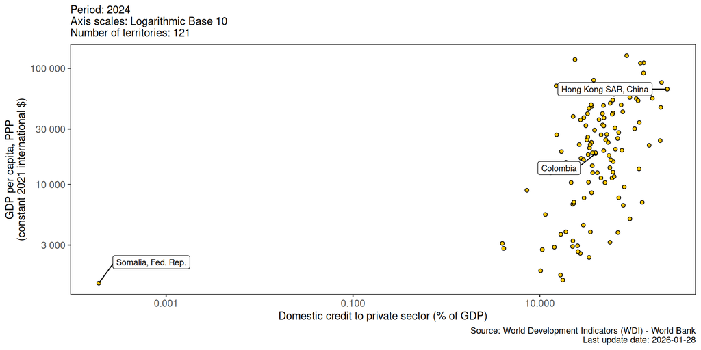

Figure 3: Financial depth vs Gross Domestic Product per-capita

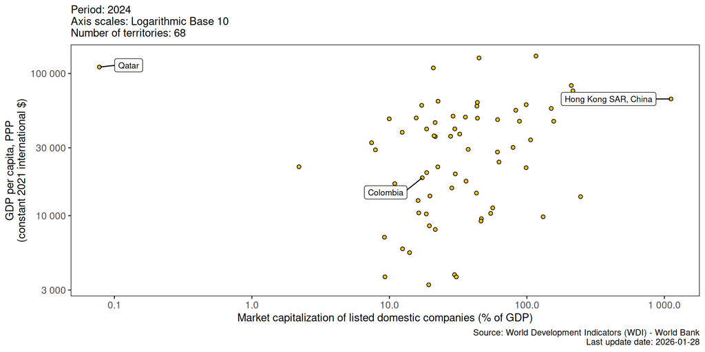

Figure 4: Financial depth vs Gross Domestic Product per-capita

# Uncertainty in financial markets

- Financing is essentially the exchange of a sum of money today for a promise to return more money in the future. Therefore it is not surprising that such exchange can be problematic
  - **Information asymmetry**: in an exchange one party has more or better information than the other
    - **Adverse selection**
    - **Moral hazard**
- **Adverse selection** occurs when it is not possible to identify the quality of a product for a party that participates in a transaction. Therefore bad products are sold with good products where the consequence is that bad products take off good products from the market (Wilson, 1987)
  - In the context of financial markets **adverse selection** occurs when an increase in interest rates induces good debtors to stop requesting loans, so that only those individuals with a higher probability of not paying the loan end up requesting loans
- **Moral hazard** is *“any situation in which one person makes the decision about how much risk to take, while someone else bears the cost if things go badly”* (Krugman, 2009, p. 63)
  - In the context of financial markets **moral hazard** occurs when debtors take riskier actions that increase the probability of default

# Acknowledgments

- To my family that supports me
- To the taxpayers of Colombia and the [**UMNG students**](https://www.umng.edu.co/estudiante) who pay my salary
- To the [**Business Science**](https://www.business-science.io/) and [**R4DS Online Learning**](https://www.rfordatasci.com/) communities where I learn [**R**](https://www.r-project.org/about.html) and [**$\pi$-thon**](https://www.python.org/about/)
- To the [**R Core Team**](https://www.r-project.org/contributors.html), the creators of [**RStudio IDE**](https://posit.co/download/rstudio-desktop/), [**Positron**](https://positron.posit.co/), [**Quarto**](https://quarto.org/) and the authors and maintainers of the packages [**tidyverse**](https://CRAN.R-project.org/package=tidyverse), [**wbstats**](https://CRAN.R-project.org/package=wbstats), [**scales**](https://CRAN.R-project.org/package=scales), [**ggrepel**](https://CRAN.R-project.org/package=ggrepel) and [**tinytex**](https://CRAN.R-project.org/package=tinytex) for allowing me to access these tools without paying for a license

# References

Bank, W. (2016). Financial Depth. In *World Bank*. https://www.worldbank.org/en/publication/gfdr/gfdr-2016/background/financial-depth

Cardenas, M. (2020). *Introducción a la Economía Colombiana* (4th ed.). Alfaomega.

Carvajal, A., Monroe, H., Wynter, B., & Pattillo, C. A. (2009). *Ponzi Schemes in the Caribbean* ({SSRN} {Scholarly} {Paper} Nos. ID 1403766). Social Science Research Network. https://papers.ssrn.com/abstract=1403766

Colombia, C. de. (1993). *Decreto 663 de 1993*. Diario Oficial No. 40.820. http://secretariasenado.gov.co/senado/basedoc/estatuto_organico_sistema_financiero.html

Hofstetter, M., Mejía, D., Rosas, J. N., & Urrutia, M. (2018). Ponzi schemes and the financial sector: DMG and DRFE in Colombia. *Journal of Banking & Finance*, *96*, 18–33. https://doi.org/10.1016/j.jbankfin.2018.08.011

Krugman, P. R. (2009). *The return of depression economics and the crisis of 2008*. W. W. Norton &amp; company.

Levine, R. (2005). Chapter 12 Finance and Growth: Theory and Evidence. In *Handbook of Economic Growth* (Vol. 1, pp. 865–934). Elsevier. https://doi.org/10.1016/S1574-0684(05)01012-9

Wilson, C. (1987). Adverse Selection. In S. Durlauf & L. E. Blume (Eds.), *The New Palgrave Dictionary of Economics* (pp. 1–4). Palgrave Macmillan UK. https://doi.org/10.1057/978-1-349-95121-5_104-1

## Footnotes

[^1]: These indicators doesn’t measure the quality of financial depth